# Analysis of Paleolithic Cave art: Relationship between Depictions and Bone Abundance

Author

Carlos Pineda

Published

October 9, 2024

[In this report I will analyze multiple data regarding cave art in the Paleolithic era. Specifically focusing on the correlation of the number of cave art of multiple animals and their bone abundance per region. The report will focus on the south west region of France. The aim of the report is to answer the following question: Is there a direct realtion between the amount of animal depicitons and the bone abundance during the Paleolithic era and what does the relation tell us? ]

```r
library(tidyverse)
my_data <-read_csv("Table 1 from Rice and Patterson 1985 - long and tidy.csv")
```

The specific data analyzed in this report is the total count of cave art of South West France , the total count of bones in the region , and the number of regions in South West France . The information and data recollected for this report is based on the findings in “Rice and Patterson 1985”

```r
# in lin R code fro my sentences
art_count <- sum(my_data$`Art count`)
```

```r
region <- sum(my_data$`Region`)
```

```r
bone_abundance <- sum(my_data$`Bone abundance`)
```

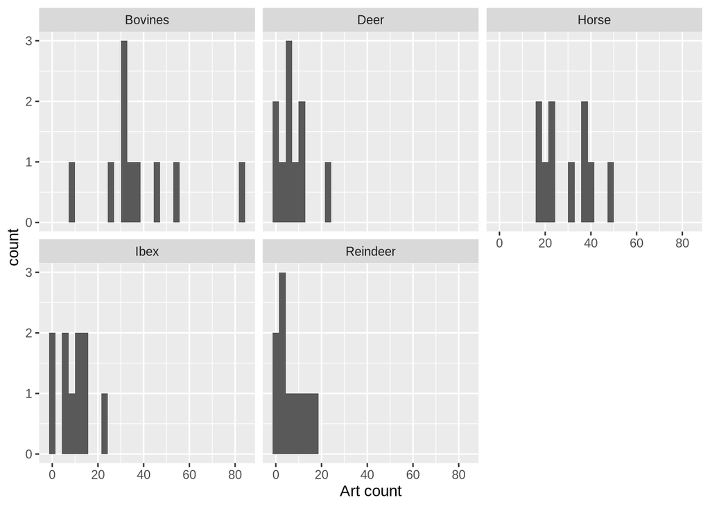

```r
ggplot(my_data) +
  aes(`Art count`) +
  geom_histogram() +
  facet_wrap(~ taxa)
```

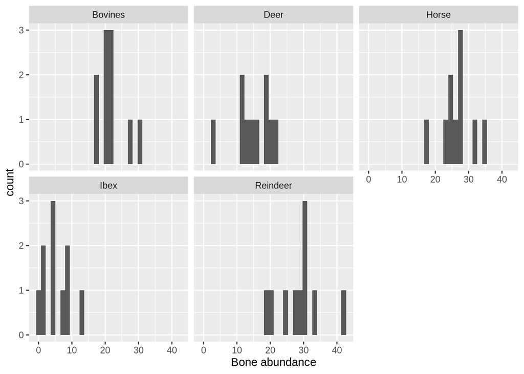

```r
ggplot(my_data) +
  aes(`Bone abundance`) +
  geom_histogram() +
  facet_wrap(~ taxa)
```

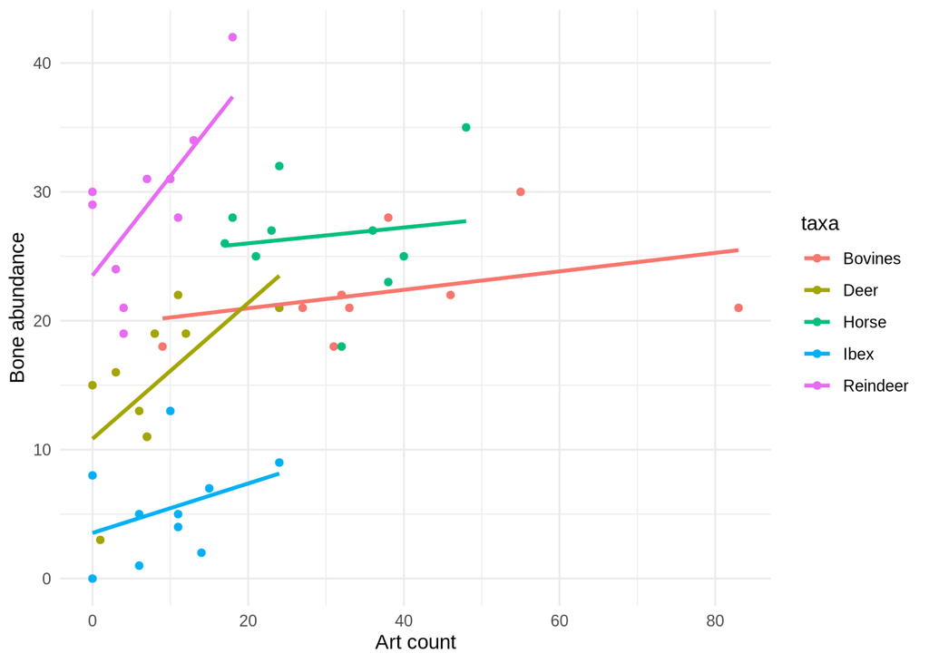

```r
ggplot(my_data) +
  aes(`Art count`,
      `Bone abundance`,
      colour = taxa) +
  geom_point() +
  geom_smooth(method = "lm",
              se = FALSE) +
  theme_minimal()
```

```r
## After analyzing the previous charts there are two key aspects to highlight. The first one is the discrepancy between the amount of reindeer and bovines cave art and the bone abundance of these animals. From the third plot we can see there is a high amount of reindeer bones, but the amount of cave art is very low. On the other hand we can see a high count of bovine cave art and not a high amount of bovine bones in the area. The second aspect to highlight is The direct relation between deer and ibex art count and their respective bone abundance
```

Rice, P. C., & Paterson, A. L. (1985). Cave Art and Bones: Exploring the interrelationships. American Anthropologist, 87(1), 94–100. https://doi.org/10.1525/aa.1985.87.1.02a00080